# Regression

Anthony Moya

2025-04-29

Este bloque de código carga las librerías necesarias para el análisis y visualización de datos: tidyverse (conjunto de paquetes útiles), datasauRus (provee el dataset), dplyr (manipulación de datos) y ggplot2 (visualización).

```r
library(tidyverse)
```

```r
library(datasauRus)
library(dplyr)
library(ggplot2)
```

Se comienza mostrando un mensaje y luego agrupa el conjunto datasaurus_dozen por nombre de dataset. Para cada grupo calcula la media y desviación estándar de las variables x e y, además de la correlación entre ambas. Esto permite comparar estadísticamente distintos conjuntos de datos que, visualmente, pueden ser muy diferentes.

```r
print("Inicio del código")
```

```
## [1] "Inicio del código"
```

```r
datasaurus_dozen %>%
  group_by(dataset) %>%
  summarize(
    mean_x = mean(x),
    mean_y = mean(y),
    std_dev_x = sd(x),
    std_dev_y = sd(y),
    corr_x_y = cor(x,y)
  )
```

```
## # A tibble: 13 × 6
##    dataset    mean_x mean_y std_dev_x std_dev_y corr_x_y
##    <chr>       <dbl>  <dbl>     <dbl>     <dbl>    <dbl>
##  1 away         54.3   47.8      16.8      26.9  -0.0641
##  2 bullseye     54.3   47.8      16.8      26.9  -0.0686
##  3 circle       54.3   47.8      16.8      26.9  -0.0683
##  4 dino         54.3   47.8      16.8      26.9  -0.0645
##  5 dots         54.3   47.8      16.8      26.9  -0.0603
##  6 h_lines      54.3   47.8      16.8      26.9  -0.0617
##  7 high_lines   54.3   47.8      16.8      26.9  -0.0685
##  8 slant_down   54.3   47.8      16.8      26.9  -0.0690
##  9 slant_up     54.3   47.8      16.8      26.9  -0.0686
## 10 star         54.3   47.8      16.8      26.9  -0.0630
## 11 v_lines      54.3   47.8      16.8      26.9  -0.0694
## 12 wide_lines   54.3   47.8      16.8      26.9  -0.0666
## 13 x_shape      54.3   47.8      16.8      26.9  -0.0656
```

Despues se genera una visualización de todos los subconjuntos del conjunto datasaurus_dozen. Usa ggplot2 para graficar los puntos (x, y) y organiza cada conjunto en una cuadrícula con facet_wrap. Se eliminan los ejes y la leyenda para resaltar únicamente las formas de los datos en cada grupo.

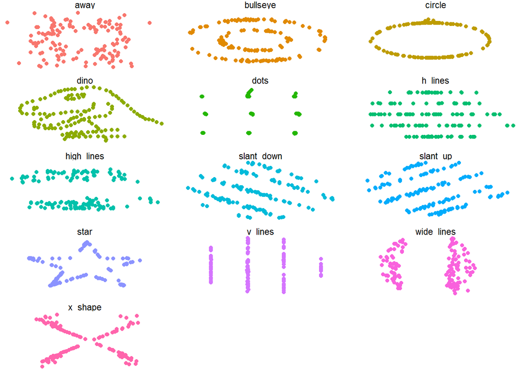

```r
ggplot(datasaurus_dozen, aes(x=x, y=y, colour = dataset))+
  geom_point()+
  theme_void()+
  theme(legend.position = "none")+
  facet_wrap(~dataset,ncol = 3)
```

Luego filtramos el conjunto datasaurus_dozen y conserva solo las observaciones del dataset llamado “dino”, que es el más representativo del conjunto por su forma de dinosaurio.

```r
datasaurus_dozen %>%
  filter(dataset == "dino")
```

```
## # A tibble: 142 × 3
##    dataset     x     y
##    <chr>   <dbl> <dbl>
##  1 dino     55.4  97.2
##  2 dino     51.5  96.0
##  3 dino     46.2  94.5
##  4 dino     42.8  91.4
##  5 dino     40.8  88.3
##  6 dino     38.7  84.9
##  7 dino     35.6  79.9
##  8 dino     33.1  77.6
##  9 dino     29.0  74.5
## 10 dino     26.2  71.4
## # ℹ 132 more rows
```

Para la regresion se filtra el dataset “dino” y lo grafica con ggplot2, mostrando los puntos en color azul y añadiendo una línea de regresión lineal en rojo punteado. Se usa un tema minimalista y se agregan etiquetas a los ejes y al título para facilitar la interpretación.

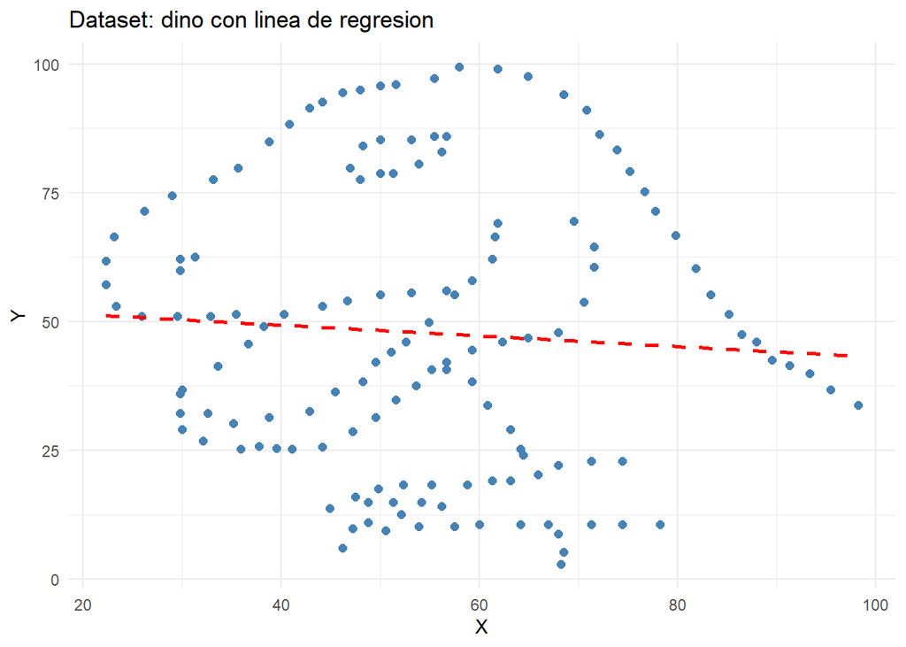

```r
datasaurus_dozen %>%
  filter(dataset == "dino") %>%
  ggplot(aes(x = x, y = y)) +
  geom_point(color = "steelblue", size = 2) +
  geom_smooth(method = "lm", se = FALSE, color = "red", linetype = "dashed") +
  theme_minimal() +
  labs(
    title = "Dataset: dino con linea de regresion",
    x = "X",
    y = "Y"
  )
```

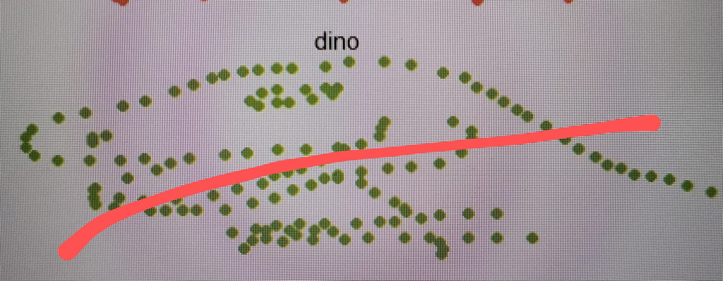

```r
knitr::include_graphics("Visual_Dino_Regression.jpg")
```

En conslusión a pesar de tener estadísticas similares, los distintos conjuntos del datasaurus_dozen muestran formas visuales muy diferentes. Esto resalta la importancia de visualizar los datos, ya que los análisis numéricos por sí solos pueden ocultar patrones significativos. La visualización es clave para una interpretación completa.